# DCGAN

### What is GAN ?

In generative models, we were always trying to estimate the data distribution by maximum likelihood approach. But in GAN we'll use a whole different approach. In this approach we have a generative network (as we had before) and we have an extra network called "Discriminator". The discriminator's duty is to recognize fake and real images from each other. The objective for the discriminator is: $$\text{argmax}_{\theta} \, \mathbb{E}_{x \sim p_{data}} \log[\mathbf{D}_{\theta}(x)] + \mathbb{E}_{x \sim p_{G_{\phi}}} \log[1-\mathbf{D}_{\theta}(x)]$$ And the objective function for generative is: $$ \text{argmin}_{\phi} \mathbb{E}_{x \sim p_{data}} \log[\mathbf{D}_{\theta}(x)] + \mathbb{E}_{x \sim p_{G_{\phi}}} \log[1-\mathbf{D}_{\theta}(x)] = \text{argmin}_{\phi} \mathbb{E}_{x \sim p_{G_{\phi}}} \log[1-\mathbf{D}_{\theta}(x)] $$

### Whats is DCGAN?

A DCGAN is a direct extension of the GAN described above, except that it explicitly uses convolutional and convolutional-transpose layers in the discriminator and generator, respectively.

### DCGAN with celeba dataset

```python
from __future__ import print_function
import argparse
import os
import random
import torch
import torch.nn as nn
import torch.nn.parallel
import torch.backends.cudnn as cudnn
import torch.optim as optim
import torch.utils.data
import torchvision
import torchvision.datasets as dset
import torchvision.transforms as transforms
import torchvision.utils as vutils
import numpy as np
import matplotlib.pyplot as plt
import matplotlib.animation as animation
from IPython.display import HTML

manualSeed = 999
random.seed(manualSeed)
torch.manual_seed(manualSeed)

print('setup done')
```

```
setup done
```

```python
# Number of workers for dataloader
workers = 2

# Batch size during training
batch_size = 64

# Spatial size of training images. All images will be resized to this
#   size using a transformer.
image_size = 64

# Number of channels in the training images. For color images this is 3
nc = 3

# Size of z latent vector (i.e. size of generator input)
nz = 100

# Size of feature maps in generator
ngf = 64

# Size of feature maps in discriminator
ndf = 64

# Number of training epochs
num_epochs = 8

# Learning rate for optimizers
lr = 0.0002

# Beta1 hyperparam for Adam optimizers
beta1 = 0.5

# Number of GPUs available. Use 0 for CPU mode.
ngpu = 1

# During Training
print_every = 100

device = torch.device("cuda:0")
```

```python
from google.colab import drive
drive.mount('/content/drive')
```

[output not shown]

```python
import zipfile
with zipfile.ZipFile("./drive/My Drive/CelebA/Img/img_align_celeba.zip", 'r') as zip_ref:
    zip_ref.extractall("./dataset")
```

#### Creating the dataset

[figure not shown]

```python
dataset_transforms = transforms.Compose([
        transforms.Resize(image_size),
        transforms.CenterCrop(image_size),
        transforms.ToTensor(),
        transforms.Normalize((0.5, 0.5, 0.5), (0.5, 0.5, 0.5)),
])

dataset = dset.ImageFolder(root='./dataset/', transform=dataset_transforms)

dataloader = torch.utils.data.DataLoader(dataset, batch_size=batch_size, shuffle=True, num_workers=workers)

real_batch = next(iter(dataloader))
plt.figure(figsize=(10,10))
plt.axis("off")
plt.title("Training Images")
plt.imshow(np.transpose(vutils.make_grid(real_batch[0].to(device)[:64], padding=2, normalize=True).cpu(),(1,2,0)))
```

#### Weight Initialization

From the DCGAN paper, the authors specify that all model weights shall be randomly initialized from a Normal distribution with mean=0, stdev=0.02. The **weights_init** function takes an initialized model as input and reinitializes all convolutional, convolutional-transpose, and batch normalization layers to meet this criteria.

```python
def weights_init(m):
    classname = m.__class__.__name__
    if classname.find('Conv') != -1:
        nn.init.normal_(m.weight.data, 0.0, 0.02)
    elif classname.find('BatchNorm') != -1:
        nn.init.normal_(m.weight.data, 1.0, 0.02)
        nn.init.constant_(m.bias.data, 0)
```

#### Generator Network

```python
class Generator(nn.Module):
    def __init__(self, ngpu):
        super(Generator, self).__init__()
        self.ngpu = ngpu
        self.main = nn.Sequential(
            nn.ConvTranspose2d(nz, ngf * 8, 4, 1, 0, bias=False),
            nn.BatchNorm2d(ngf * 8),
            nn.ReLU(True),
            nn.ConvTranspose2d(ngf * 8, ngf * 4, 4, 2, 1, bias=False),
            nn.BatchNorm2d(ngf * 4),
            nn.ReLU(True),
            nn.ConvTranspose2d(ngf * 4, ngf * 2, 4, 2, 1, bias=False),
            nn.BatchNorm2d(ngf * 2),
            nn.ReLU(True),
            nn.ConvTranspose2d(ngf * 2, ngf, 4, 2, 1, bias=False),
            nn.BatchNorm2d(ngf),
            nn.ReLU(True),
            nn.ConvTranspose2d(ngf, nc, 4, 2, 1, bias=False),
            nn.Tanh()
        )

    def forward(self, input):
        return self.main(input)
```

#### Instantiate the generator

```python
netG = Generator(ngpu).to(device)

netG.apply(weights_init)

print(netG)
```

```
Generator(
  (main): Sequential(
    (0): ConvTranspose2d(100, 512, kernel_size=(4, 4), stride=(1, 1), bias=False)
    (1): BatchNorm2d(512, eps=1e-05, momentum=0.1, affine=True, track_running_stats=True)
    (2): ReLU(inplace=True)
    (3): ConvTranspose2d(512, 256, kernel_size=(4, 4), stride=(2, 2), padding=(1, 1), bias=False)
    (4): BatchNorm2d(256, eps=1e-05, momentum=0.1, affine=True, track_running_stats=True)
    (5): ReLU(inplace=True)
    (6): ConvTranspose2d(256, 128, kernel_size=(4, 4), stride=(2, 2), padding=(1, 1), bias=False)
    (7): BatchNorm2d(128, eps=1e-05, momentum=0.1, affine=True, track_running_stats=True)
    (8): ReLU(inplace=True)
    (9): ConvTranspose2d(128, 64, kernel_size=(4, 4), stride=(2, 2), padding=(1, 1), bias=False)
    (10): BatchNorm2d(64, eps=1e-05, momentum=0.1, affine=True, track_running_stats=True)
    (11): ReLU(inplace=True)
    (12): ConvTranspose2d(64, 3, kernel_size=(4, 4), stride=(2, 2), padding=(1, 1), bias=False)
    (13): Tanh()
  )
)
```

#### Discriminator

As mentioned, the discriminator, $\mathbb D$, is a binary classification network that takes an image as input and outputs a scalar probability that the input image is real (as opposed to fake). Here, $\mathbb D$ takes a 3x64x64 input image, processes it through a series of Conv2d, BatchNorm2d, and LeakyReLU layers, and outputs the final probability through a Sigmoid activation function. This architecture can be extended with more layers if necessary for the problem, but there is significance to the use of the strided convolution, BatchNorm, and LeakyReLUs. The DCGAN paper mentions it is a good practice to use strided convolution rather than pooling to downsample because it lets the network learn its own pooling function. Also batch norm and leaky relu functions promote healthy gradient flow which is critical for the learning process of both G and D.

```python
class Discriminator(nn.Module):
    def __init__(self, ngpu):
        super(Discriminator, self).__init__()
        self.ngpu = ngpu
        self.main = nn.Sequential(
            nn.Conv2d(nc, ndf, 4, 2, 1, bias=False),
            nn.LeakyReLU(0.2, inplace=True),
            nn.Conv2d(ndf, ndf * 2, 4, 2, 1, bias=False),
            nn.BatchNorm2d(ndf * 2),
            nn.LeakyReLU(0.2, inplace=True),
            nn.Conv2d(ndf * 2, ndf * 4, 4, 2, 1, bias=False),
            nn.BatchNorm2d(ndf * 4),
            nn.LeakyReLU(0.2, inplace=True),
            nn.Conv2d(ndf * 4, ndf * 8, 4, 2, 1, bias=False),
            nn.BatchNorm2d(ndf * 8),
            nn.LeakyReLU(0.2, inplace=True),
            nn.Conv2d(ndf * 8, 1, 4, 1, 0, bias=False),
            nn.Sigmoid()
        )

    def forward(self, input):
        return self.main(input)
```

```python
netD = Discriminator(ngpu).to(device)

netD.apply(weights_init)

print(netD)
```

```
Discriminator(
  (main): Sequential(
    (0): Conv2d(3, 64, kernel_size=(4, 4), stride=(2, 2), padding=(1, 1), bias=False)
    (1): LeakyReLU(negative_slope=0.2, inplace=True)
    (2): Conv2d(64, 128, kernel_size=(4, 4), stride=(2, 2), padding=(1, 1), bias=False)
    (3): BatchNorm2d(128, eps=1e-05, momentum=0.1, affine=True, track_running_stats=True)
    (4): LeakyReLU(negative_slope=0.2, inplace=True)
    (5): Conv2d(128, 256, kernel_size=(4, 4), stride=(2, 2), padding=(1, 1), bias=False)
    (6): BatchNorm2d(256, eps=1e-05, momentum=0.1, affine=True, track_running_stats=True)
    (7): LeakyReLU(negative_slope=0.2, inplace=True)
    (8): Conv2d(256, 512, kernel_size=(4, 4), stride=(2, 2), padding=(1, 1), bias=False)
    (9): BatchNorm2d(512, eps=1e-05, momentum=0.1, affine=True, track_running_stats=True)
    (10): LeakyReLU(negative_slope=0.2, inplace=True)
    (11): Conv2d(512, 1, kernel_size=(4, 4), stride=(1, 1), bias=False)
    (12): Sigmoid()
  )
)
```

#### Loss Functions and Optimizers

With D and G setup, we can specify how they learn through the loss functions and optimizers. We will use the Binary Cross Entropy loss (BCELoss) function.Next, we define our real label as 1 and the fake label as 0. These labels will be used when calculating the losses of D and G, and this is also the convention used in the original GAN paper.  
Finally, we set up two separate optimizers, one for D and one for G. As specified in the DCGAN paper, both are Adam optimizers with learning rate 0.0002 and Beta1 = 0.5.

```python
criterion = nn.BCELoss()

fixed_noise = torch.randn(64, nz, 1, 1, device=device)

real_label = 1
fake_label = 0

optimizerD = optim.Adam(netD.parameters(), lr=lr, betas=(beta1, 0.999))
optimizerG = optim.Adam(netG.parameters(), lr=lr, betas=(beta1, 0.999))
```

#### Training

##### **Train the Discriminator**

The goal of training the discriminator is to maximize the probability of correctly classifying a given input as real or fake. Due to the separate mini-batch suggestion from ganhacks, we will calculate this in two steps. First, we will construct a batch of real samples from the training set, forward pass through D, calculate the loss $\log(D(x))$, then calculate the gradients in a backward pass. Secondly, we will construct a batch of fake samples with the current generator, forward pass this batch through D, calculate the loss $\log(1−D(G(z)))$, and accumulate the gradients with a backward pass. Now, with the gradients accumulated from both the all-real and all-fake batches, we call a step of the Discriminator’s optimizer.

##### **Train the Generator**

As stated in the original paper, we want to train the Generator by minimizing $\log(1−D(G(z)))$ in an effort to generate better fakes. As mentioned, this was shown by Goodfellow to not provide sufficient gradients, especially early in the learning process. As a fix, we instead wish to maximize $\log(D(G(z)))$. In the code we accomplish this by: classifying the Generator output from Part 1 with the Discriminator, computing G’s loss using real labels as GT, computing G’s gradients in a backward pass, and finally updating G’s parameters with an optimizer step.

```python
img_list = []
G_losses = []
D_losses = []
iters = 0

print("Training has start...")

for epoch in range(num_epochs):

    for i, data in enumerate(dataloader, 0):

        ############################
        # (1) Update D network: maximize log(D(x)) + log(1 - D(G(z)))
        ###########################

        ## Train with all-real batch
        netD.zero_grad()

        real_data = data[0].to(device)
        b_size = real_data.size(0)
        label = torch.full((b_size,), real_label, device=device)

        output = netD(real_data).view(-1)
        errD_real = criterion(output, label)

        errD_real.backward()
        D_x = output.mean().item()

        ## Train with all-fake batch
        noise = torch.randn(b_size, nz, 1, 1, device=device)

        fake = netG(noise)
        label.fill_(fake_label)

        output = netD(fake.detach()).view(-1)
        errD_fake = criterion(output, label)

        errD_fake.backward()
        D_G_z1 = output.mean().item()

        errD = errD_real + errD_fake

        optimizerD.step()

        ############################
        # (2) Update G network: maximize log(D(G(z)))
        ###########################

        netG.zero_grad()
        label.fill_(real_label)
        output = netD(fake).view(-1)

        errG = criterion(output, label)
        errG.backward()
        D_G_z2 = output.mean().item()

        optimizerG.step()

        # Output training stats
        if i % print_every == 0:
            print('[%d/%d][%d/%d]\tLoss_D: %.4f\tLoss_G: %.4f\tD(x): %.4f\tD(G(z)): %.4f / %.4f'
                  % (epoch, num_epochs, i, len(dataloader),
                     errD.item(), errG.item(), D_x, D_G_z1, D_G_z2))

        G_losses.append(errG.item())
        D_losses.append(errD.item())

        if (iters % 500 == 0) or ((epoch == num_epochs-1) and (i == len(dataloader)-1)):
            with torch.no_grad():
                fake = netG(fixed_noise).detach().cpu()
            img_list.append(vutils.make_grid(fake, padding=2, normalize=True))

        iters += 1
```

```
Training has start...
```

```
[0/8][0/3166]	Loss_D: 1.8936	Loss_G: 2.2388	D(x): 0.2863	D(G(z)): 0.2728 / 0.1320
[0/8][100/3166]	Loss_D: 0.0133	Loss_G: 8.5961	D(x): 0.9885	D(G(z)): 0.0004 / 0.0006
[0/8][200/3166]	Loss_D: 0.4694	Loss_G: 4.7477	D(x): 0.8539	D(G(z)): 0.2000 / 0.0154
[0/8][300/3166]	Loss_D: 0.2546	Loss_G: 5.6969	D(x): 0.8661	D(G(z)): 0.0716 / 0.0071
[0/8][400/3166]	Loss_D: 0.4689	Loss_G: 3.6638	D(x): 0.7465	D(G(z)): 0.1026 / 0.0538
[0/8][500/3166]	Loss_D: 0.3897	Loss_G: 3.9291	D(x): 0.7796	D(G(z)): 0.0385 / 0.0335
[0/8][600/3166]	Loss_D: 0.4364	Loss_G: 4.9738	D(x): 0.9466	D(G(z)): 0.2656 / 0.0141
[0/8][700/3166]	Loss_D: 1.3195	Loss_G: 9.2351	D(x): 0.9689	D(G(z)): 0.6303 / 0.0003
[0/8][800/3166]	Loss_D: 0.9513	Loss_G: 4.1941	D(x): 0.8638	D(G(z)): 0.4203 / 0.0277
[0/8][900/3166]	Loss_D: 0.3803	Loss_G: 4.6915	D(x): 0.8711	D(G(z)): 0.1756 / 0.0146
[0/8][1000/3166]	Loss_D: 1.2935	Loss_G: 2.2750	D(x): 0.4329	D(G(z)): 0.0048 / 0.2783
[0/8][1100/3166]	Loss_D: 0.9997	Loss_G: 5.3613	D(x): 0.8853	D(G(z)): 0.4366 / 0.0130
[0/8][1200/3166]	Loss_D: 0.2030	Loss_G: 3.5247	D(x): 0.8809	D(G(z)): 0.0384 / 0.0566
[0/8][1300/3166]	Loss_D: 0.4398	Loss_G: 3.8295	D(x): 0.8511	D(G(z)): 0.1854 / 0.0389
[0/8][1400/3166]	Loss_D: 0.8163	Loss_G: 3.7583	D(x): 0.7828	D(G(z)): 0.3086 / 0.0402
[0/8][1500/3166]	Loss_D: 0.7599	Loss_G: 3.6483	D(x): 0.5971	D(G(z)): 0.0489 / 0.0607
[0/8][1600/3166]	Loss_D: 0.2219	Loss_G: 4.3567	D(x): 0.9606	D(G(z)): 0.1495 / 0.0199
[0/8][1700/3166]	Loss_D: 0.4567	Loss_G: 3.9849	D(x): 0.8352	D(G(z)): 0.1808 / 0.0319
[0/8][1800/3166]	Loss_D: 0.3616	Loss_G: 3.7590	D(x): 0.9216	D(G(z)): 0.2157 / 0.0346
[0/8][1900/3166]	Loss_D: 0.8569	Loss_G: 6.0647	D(x): 0.9663	D(G(z)): 0.4580 / 0.0056
[0/8][2000/3166]	Loss_D: 0.5795	Loss_G: 6.5512	D(x): 0.8921	D(G(z)): 0.3148 / 0.0029
[0/8][2100/3166]	Loss_D: 0.4839	Loss_G: 3.0340	D(x): 0.8068	D(G(z)): 0.1773 / 0.0757
[0/8][2200/3166]	Loss_D: 0.5381	Loss_G: 3.6563	D(x): 0.6789	D(G(z)): 0.0412 / 0.0519
[0/8][2300/3166]	Loss_D: 0.5467	Loss_G: 1.6393	D(x): 0.6769	D(G(z)): 0.0679 / 0.2557
[0/8][2400/3166]	Loss_D: 0.2790	Loss_G: 3.7644	D(x): 0.9160	D(G(z)): 0.1549 / 0.0346
[0/8][2500/3166]	Loss_D: 0.6738	Loss_G: 5.8538	D(x): 0.9223	D(G(z)): 0.3852 / 0.0045
[0/8][2600/3166]	Loss_D: 0.2253	Loss_G: 4.6969	D(x): 0.8652	D(G(z)): 0.0617 / 0.0160
[0/8][2700/3166]	Loss_D: 0.4828	Loss_G: 4.8404	D(x): 0.9061	D(G(z)): 0.2708 / 0.0139
[0/8][2800/3166]	Loss_D: 0.3180	Loss_G: 3.5608	D(x): 0.9054	D(G(z)): 0.1737 / 0.0444
[0/8][2900/3166]	Loss_D: 0.2148	Loss_G: 4.2644	D(x): 0.9414	D(G(z)): 0.1320 / 0.0215
[0/8][3000/3166]	Loss_D: 0.5635	Loss_G: 2.5841	D(x): 0.6284	D(G(z)): 0.0340 / 0.1164
[0/8][3100/3166]	Loss_D: 0.3310	Loss_G: 3.1584	D(x): 0.8708	D(G(z)): 0.1452 / 0.0589
[1/8][0/3166]	Loss_D: 0.3651	Loss_G: 3.4122	D(x): 0.8886	D(G(z)): 0.1917 / 0.0446
[1/8][100/3166]	Loss_D: 0.3528	Loss_G: 2.9945	D(x): 0.8328	D(G(z)): 0.1264 / 0.0740
[1/8][200/3166]	Loss_D: 1.2150	Loss_G: 0.8502	D(x): 0.4032	D(G(z)): 0.0385 / 0.4860
[1/8][300/3166]	Loss_D: 0.7279	Loss_G: 4.2306	D(x): 0.9159	D(G(z)): 0.4131 / 0.0257
[1/8][400/3166]	Loss_D: 0.3303	Loss_G: 3.3424	D(x): 0.8439	D(G(z)): 0.1167 / 0.0568
[1/8][500/3166]	Loss_D: 0.5647	Loss_G: 3.9247	D(x): 0.8698	D(G(z)): 0.2848 / 0.0326
[1/8][600/3166]	Loss_D: 0.8379	Loss_G: 3.2323	D(x): 0.6787	D(G(z)): 0.2589 / 0.0656
[1/8][700/3166]	Loss_D: 0.9890	Loss_G: 1.3356	D(x): 0.4470	D(G(z)): 0.0289 / 0.3223
```

[output cut: 201 more lines]

```
[7/8][1700/3166]	Loss_D: 0.4434	Loss_G: 3.4116	D(x): 0.7259	D(G(z)): 0.0478 / 0.0631
[7/8][1800/3166]	Loss_D: 0.2999	Loss_G: 2.8661	D(x): 0.8080	D(G(z)): 0.0479 / 0.0895
[7/8][1900/3166]	Loss_D: 0.2273	Loss_G: 2.7873	D(x): 0.8595	D(G(z)): 0.0427 / 0.1115
[7/8][2000/3166]	Loss_D: 0.0678	Loss_G: 4.9847	D(x): 0.9805	D(G(z)): 0.0454 / 0.0113
[7/8][2100/3166]	Loss_D: 1.9291	Loss_G: 6.9054	D(x): 0.9799	D(G(z)): 0.7731 / 0.0026
[7/8][2200/3166]	Loss_D: 0.2833	Loss_G: 2.2991	D(x): 0.8544	D(G(z)): 0.0871 / 0.1487
[7/8][2300/3166]	Loss_D: 0.1668	Loss_G: 4.2559	D(x): 0.9511	D(G(z)): 0.0873 / 0.0244
[7/8][2400/3166]	Loss_D: 0.2391	Loss_G: 3.2212	D(x): 0.8306	D(G(z)): 0.0309 / 0.0714
[7/8][2500/3166]	Loss_D: 0.2725	Loss_G: 3.4166	D(x): 0.8926	D(G(z)): 0.0991 / 0.0523
[7/8][2600/3166]	Loss_D: 0.0685	Loss_G: 4.4940	D(x): 0.9746	D(G(z)): 0.0404 / 0.0202
[7/8][2700/3166]	Loss_D: 0.4052	Loss_G: 5.9562	D(x): 0.9908	D(G(z)): 0.2822 / 0.0049
[7/8][2800/3166]	Loss_D: 0.2882	Loss_G: 4.6913	D(x): 0.8552	D(G(z)): 0.0917 / 0.0201
[7/8][2900/3166]	Loss_D: 0.3084	Loss_G: 2.6694	D(x): 0.8255	D(G(z)): 0.0585 / 0.1121
[7/8][3000/3166]	Loss_D: 0.0983	Loss_G: 4.1443	D(x): 0.9541	D(G(z)): 0.0461 / 0.0257
[7/8][3100/3166]	Loss_D: 0.0793	Loss_G: 5.3754	D(x): 0.9851	D(G(z)): 0.0596 / 0.0068
```

```python
! mkdir ./model
! mkdir ./model/G
! mkdir ./model/D

! touch ./model/G/model.dms
! touch ./model/D/model.dms
```

```
mkdir: cannot create directory ‘./model’: File exists
mkdir: cannot create directory ‘./model/G’: File exists
mkdir: cannot create directory ‘./model/D’: File exists
```

```python
torch.save({
    'model_state_dict': netG.state_dict(),
}, './model/G/model.dms')

torch.save({
    'model_state_dict': netD.state_dict(),
}, './model/D/model.dms')
```

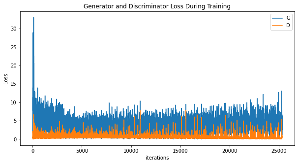

```python
plt.figure(figsize=(10,5))
plt.title("Generator and Discriminator Loss During Training")
plt.plot(G_losses,label="G")
plt.plot(D_losses,label="D")
plt.xlabel("iterations")
plt.ylabel("Loss")
plt.legend()
plt.show()
```

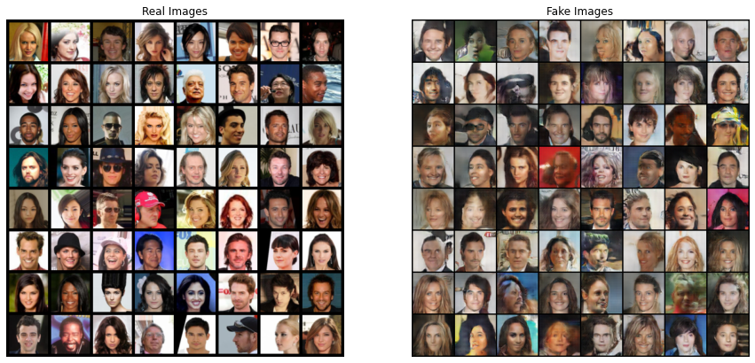

```python
real_batch = next(iter(dataloader))

# Plot the real images
plt.figure(figsize=(15,15))
plt.subplot(1,2,1)
plt.axis("off")
plt.title("Real Images")
plt.imshow(np.transpose(vutils.make_grid(real_batch[0].to(device)[:64], padding=5, normalize=True).cpu(),(1,2,0)))

# Plot the fake images from the last epoch
plt.subplot(1,2,2)
plt.axis("off")
plt.title("Fake Images")
plt.imshow(np.transpose(img_list[-1],(1,2,0)))
plt.show()
```